# Final2

Harry Woo

2020 6 12

### Problem 2

https://socialsciences.mcmaster.ca/jfox/Courses/SPIDA/ https://sms.wgtn.ac.nz/foswiki/pub/Courses/DATA303_2020T1/Lab2/lab2.html https://sms.wgtn.ac.nz/foswiki/pub/Courses/DATA303_2020T1/Lab3/lab3.html https://sms.wgtn.ac.nz/foswiki/pub/Courses/DATA303_2020T1/Lab4/lab4.html http://www.jpstats.org/Regression/ch_05_05.html

*After exploring the data graphically, perform a linear least‐squares regression of the total fertility rate (`tfr`) on GDP per capita (`GDPperCapita`), the female illiteracy rate (`illiteracyFemale`), and the rate of contraceptive use by married women (`contraception`).*

*Introduce the factor `region` into the regression, first fitting an additive model to the data and then considering the possibility that region interacts with the other explanatory variables.*

#### 2.0 Data loading

```r
un <- read.table("http://socialsciences.mcmaster.ca/jfox/Books/Applied-Regression-2E/datasets/UnitedNations.txt", header = TRUE)

str(un)
```

```
## 'data.frame':    207 obs. of  13 variables:
##  $ region                : chr  "Asia" "Europe" "Africa" "Asia" ...
##  $ tfr                   : num  6.9 2.6 3.81 NA NA 6.69 NA 2.62 1.7 1.89 ...
##  $ contraception         : int  NA NA 52 NA NA NA 53 NA 22 76 ...
##  $ educationMale         : num  NA NA 11.1 NA NA NA NA NA NA 16.3 ...
##  $ educationFemale       : num  NA NA 9.9 NA NA NA NA NA NA 16.1 ...
##  $ lifeMale              : num  45 68 67.5 68 NA 44.9 NA 69.6 67.2 75.4 ...
##  $ lifeFemale            : num  46 74 70.3 73 NA 48.1 NA 76.8 74 81.2 ...
##  $ infantMortality       : int  154 32 44 11 NA 124 24 22 25 6 ...
##  $ GDPperCapita          : int  2848 863 1531 NA NA 355 6966 8055 354 20046 ...
##  $ economicActivityMale  : num  87.5 NA 76.4 58.8 NA NA 74.4 76.2 65 74 ...
##  $ economicActivityFemale: num  7.2 NA 7.8 42.4 NA NA 56.2 41.3 52 53.8 ...
##  $ illiteracyMale        : num  52.8 NA 26.1 0.264 NA NA NA 3.8 0.3 NA ...
##  $ illiteracyFemale      : num  85 NA 51 0.36 NA NA NA 3.8 0.5 NA ...
```

```r
summary(un)
```

```
##     region               tfr        contraception   educationMale
##  Length:207         Min.   :1.190   Min.   : 2.00   Min.   : 3.30
##  Class :character   1st Qu.:1.950   1st Qu.:21.00   1st Qu.: 9.75
##  Mode  :character   Median :3.070   Median :47.00   Median :11.25
##                     Mean   :3.529   Mean   :43.43   Mean   :11.41
##                     3rd Qu.:4.980   3rd Qu.:64.00   3rd Qu.:13.90
##                     Max.   :8.000   Max.   :86.00   Max.   :17.20
##                     NA's   :10      NA's   :63      NA's   :131
##  educationFemale     lifeMale       lifeFemale    infantMortality
##  Min.   : 2.000   Min.   :36.00   Min.   :39.10   Min.   :  2.00
##  1st Qu.: 9.325   1st Qu.:57.38   1st Qu.:59.60   1st Qu.: 12.00
##  Median :11.650   Median :66.50   Median :72.15   Median : 30.00
##  Mean   :11.275   Mean   :63.63   Mean   :68.39   Mean   : 43.48
##  3rd Qu.:13.650   3rd Qu.:70.90   3rd Qu.:76.42   3rd Qu.: 66.00
##  Max.   :17.800   Max.   :77.40   Max.   :82.90   Max.   :169.00
##  NA's   :131      NA's   :11      NA's   :11      NA's   :6
##   GDPperCapita   economicActivityMale economicActivityFemale illiteracyMale
##  Min.   :   36   Min.   :51.20        Min.   : 1.90          Min.   : 0.200
##  1st Qu.:  442   1st Qu.:72.30        1st Qu.:37.00          1st Qu.: 2.952
##  Median : 1779   Median :76.80        Median :48.40          Median :10.829
##  Mean   : 6262   Mean   :76.46        Mean   :46.79          Mean   :17.555
##  3rd Qu.: 7272   3rd Qu.:81.20        3rd Qu.:56.40          3rd Qu.:27.575
##  Max.   :42416   Max.   :93.00        Max.   :90.60          Max.   :79.100
##  NA's   :10      NA's   :42           NA's   :42             NA's   :47
##  illiteracyFemale
##  Min.   : 0.200
##  1st Qu.: 4.847
##  Median :20.100
##  Mean   :27.906
##  3rd Qu.:48.025
##  Max.   :93.400
##  NA's   :47
```

데이터를 `un`으로 로딩한 후 기술통계량을 확인한 결과, 상당수의 결측치가 존재하는 것으로 확인되는 바, 우선 결측치 처리를 진행해야 하는 것으로 판단된다.

```r
# NA 처리, 변수 선택
un2 <- na.omit(un[,c("tfr", "GDPperCapita", "illiteracyFemale", "contraception", "region")])
```

`na.omit`으로 결측치를 제거하고, 문제에서 제시한 변수인 `tfr`, `GDPperCapita`, `illiteracyFemale`, `contraception`, `region` 을 선택하여 `un2`로 저장하였다.

#### 2.1 Exploring the data graphically

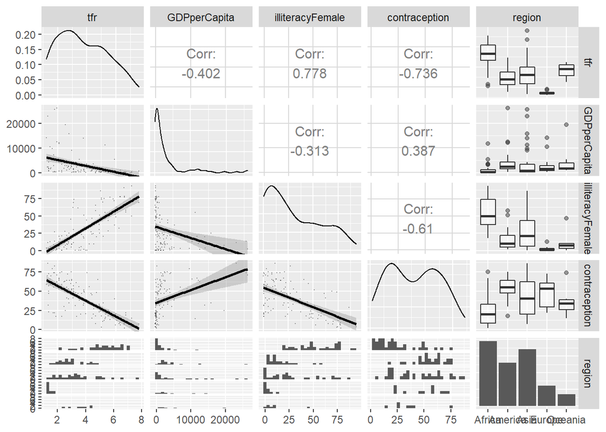

```r
ggpairs(un2,
        lower = list(continuous = wrap("smooth", alpha = 0.3, size = 0.1)),
        diag = list(discrete="barDiag", continuous = wrap("densityDiag", alpha = 0.5 )),
        upper = list(combo = wrap("box_no_facet", alpha = 0.5),
                     continuous = wrap("cor", size = 4,alignPercent = 0.8))) +
  theme(legend.position = "bottom")
```

산점도/상관계수 행렬을 통해 살펴본 결과, `GPDperCapita`와 `illiteracyFemale` 두 변수는 치우침을 고려하여 log transformation을 시도할 필요가 있는 것으로 보인다. 종속변수 `tfr`은 `GDPperCapita` 및 `Contraception`과 음의 상관관계를, `illiteracyFemale`과는 양의 상관관계를 가지며, 적합된 회귀선의 양상으로는 다른 변수들 간에도 상관관계가 존재하는 것으로 보인다.

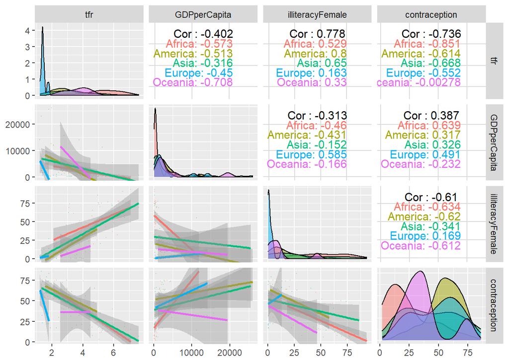

```r
# by region
ggpairs(un2[,1:4], aes(colour = un2$region),
        lower = list(continuous = wrap("smooth", alpha = 0.3, size = 0.1)),
        diag = list(discrete="barDiag", continuous = wrap("densityDiag", alpha = 0.5 )),
        upper = list(combo = wrap("box_no_facet", alpha = 0.5),
                     continuous = wrap("cor", size = 4,alignPercent = 0.8))) +
  theme(legend.position = "bottom")
```

`region` 변수의 영향을 확인하기 위해 새로운 산점도/상관계수 행렬을 작성하였다. 특히 치우친 형태의 분포를 보이던 변수들의 분포를 지역을 기준으로 다시 그리자 지역별로 양상이 크게 다르게 나타나며, 특히 유럽이 다른 지역과 차이를 보이는 것을 확인할 수 있다. 향후 모델에 `region` 변수를 추가하는 것이 합리적인 것으로 판단된다.

#### 2.2 Linear least-squares regression

```r
un_lm <- lm(tfr ~ GDPperCapita + illiteracyFemale + contraception, data = un2)
summary(un_lm)
```

```
##
## Call:
## lm(formula = tfr ~ GDPperCapita + illiteracyFemale + contraception,
##     data = un2)
##
## Residuals:
##      Min       1Q   Median       3Q      Max
## -2.02594 -0.58644  0.08299  0.51946  2.17032
##
## Coefficients:
##                    Estimate Std. Error t value Pr(>|t|)
## (Intercept)       4.021e+00  2.837e-01  14.175  < 2e-16 ***
## GDPperCapita     -2.998e-05  1.771e-05  -1.693   0.0933 .
## illiteracyFemale  3.188e-02  3.905e-03   8.165 4.83e-13 ***
## contraception    -2.884e-02  4.800e-03  -6.008 2.30e-08 ***
## ---
## Signif. codes:  0 '***' 0.001 '**' 0.01 '*' 0.05 '.' 0.1 ' ' 1
##
## Residual standard error: 0.8952 on 114 degrees of freedom
## Multiple R-squared:  0.7212, Adjusted R-squared:  0.7138
## F-statistic: 98.28 on 3 and 114 DF,  p-value: < 2.2e-16
```

문제에서 주어진 바와 같이 `region`을 제외한 설명변수를 기준으로 회귀모형 `un_lm`을 적합하였다. `illiteracyFemale`과 `contraception`이 매우 유의하게 나타났고, 의아하게도 `GDPperCapita`는 유의수준 0.05에서 유의하지 않은 것으로 나타났다. 결정계수는 72% 수준으로 양호하다.

##### Diagnosis

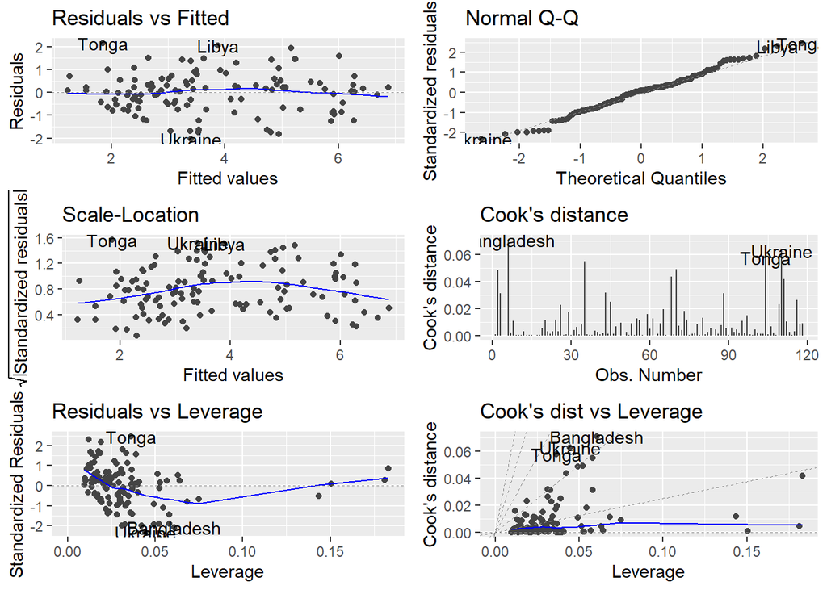

```r
autoplot(un_lm, which = c(1:6))
```

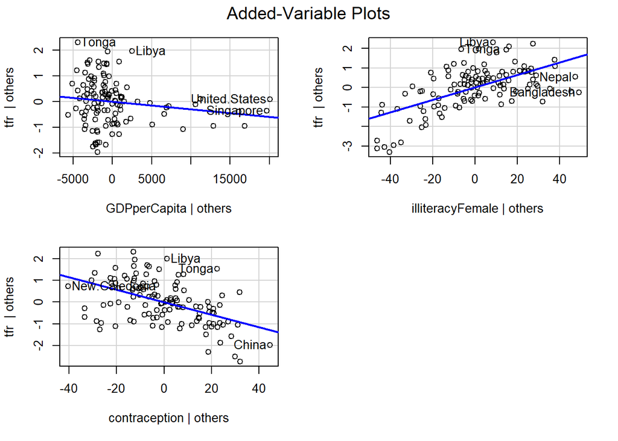

```r
avPlots(un_lm, ask=FALSE)
```

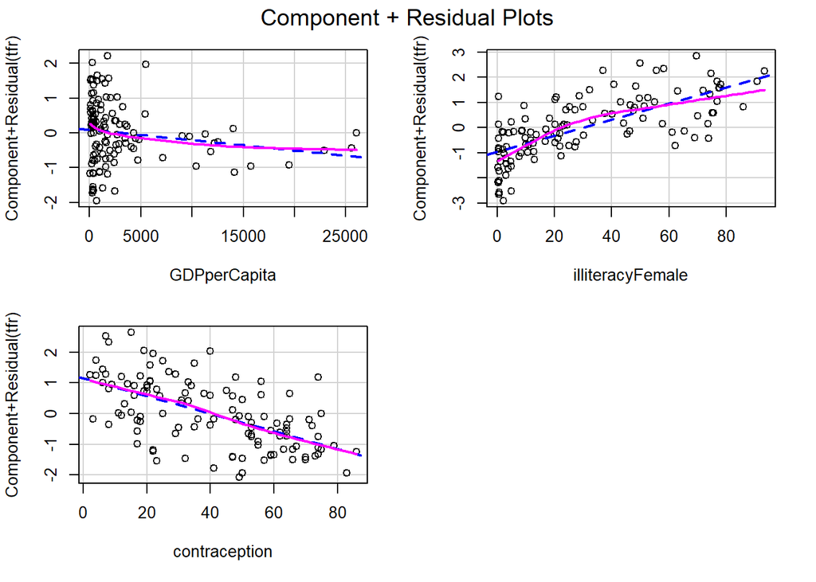

```r
crPlots(un_lm, ask=FALSE)
```

Regression diagnostic plot을 통해 확인한 결과, 오차의 선형성, 정규성, 등분산성에는 큰 문제가 없는 것으로 판단된다. Outlier 및 influential point와 관련하여서도 Tonga, Bangladesh 등의 데이터가 반복적으로 튀고 있으나 cook’s distance 수치가 양호하며 added variable plot 상에서도 큰 이슈는 없는 것으로 보인다.

그러나 Component+residual plot을 통해 확인한 결과 `GDPperCapita`와 `illiteracyFemale`에 nonlinearity 이슈가 있는 것으로 판단되는 바, 최초 graphical 분석에서 확인한 바와 같이 두 변수에 log transformation을 시도하였다.

##### Log transformation

```r
un_lm2 <- lm(tfr ~ log(GDPperCapita) + log(illiteracyFemale) + contraception, data = un2)
summary(un_lm2)
```

```
##
## Call:
## lm(formula = tfr ~ log(GDPperCapita) + log(illiteracyFemale) +
##     contraception, data = un2)
##
## Residuals:
##      Min       1Q   Median       3Q      Max
## -2.31858 -0.54751 -0.00501  0.50938  3.05329
##
## Coefficients:
##                        Estimate Std. Error t value Pr(>|t|)
## (Intercept)            5.520983   0.477317  11.567  < 2e-16 ***
## log(GDPperCapita)     -0.237220   0.070972  -3.342  0.00112 **
## log(illiteracyFemale)  0.465621   0.052299   8.903 9.85e-15 ***
## contraception         -0.033228   0.004569  -7.272 4.79e-11 ***
## ---
## Signif. codes:  0 '***' 0.001 '**' 0.01 '*' 0.05 '.' 0.1 ' ' 1
##
## Residual standard error: 0.8528 on 114 degrees of freedom
## Multiple R-squared:  0.7469, Adjusted R-squared:  0.7402
## F-statistic: 112.1 on 3 and 114 DF,  p-value: < 2.2e-16
```

```r
anova(un_lm, un_lm2)
```

```
## Analysis of Variance Table
##
## Model 1: tfr ~ GDPperCapita + illiteracyFemale + contraception
## Model 2: tfr ~ log(GDPperCapita) + log(illiteracyFemale) + contraception
##   Res.Df    RSS Df Sum of Sq F Pr(>F)
## 1    114 91.348
## 2    114 82.916  0    8.4326
```

로그변환 후 회귀모형을 `un_lm2`로 적합하여 summary를 확인한 결과, 세 설명변수가 모두 유의하며, 특히 인당 GDP 변수가 통계적으로 유의한 것으로 확인되었다. 결정계수 또한 소폭 향상되었다.

##### Diagnosis (2)

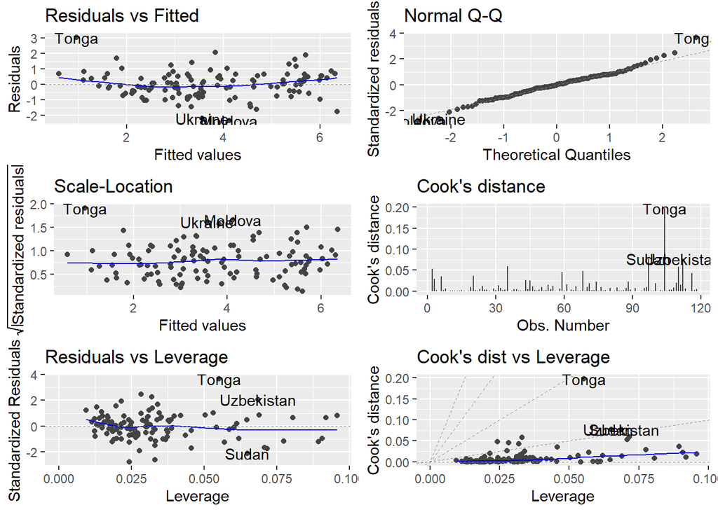

```r
autoplot(un_lm2, which = c(1:6))
```

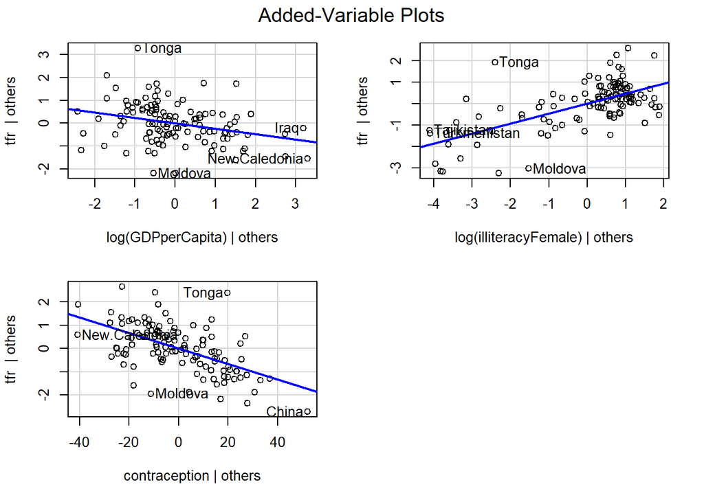

```r
avPlots(un_lm2, ask=FALSE)
```

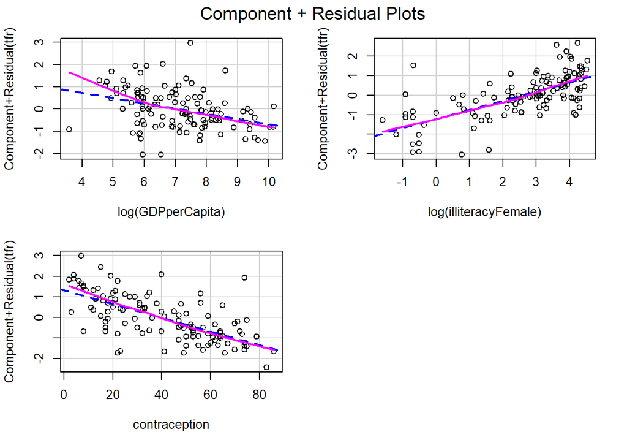

```r
crPlots(un_lm2, ask=FALSE)
```

```r
un2[row.names(un2) == "Tonga",]
```

```
##        tfr GDPperCapita illiteracyFemale contraception  region
## Tonga 4.02         1787            0.504            74 Oceania
```

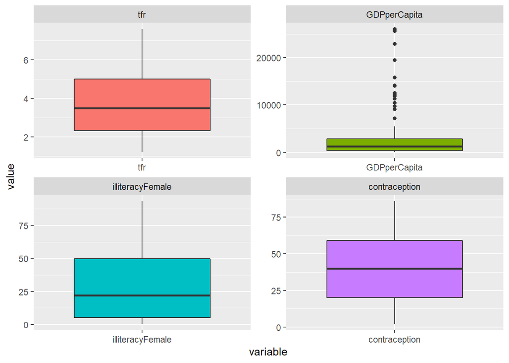

```r
# multiple boxplot using reshape2 package
ggplot(data = melt(un2[,1:4]), aes(x = variable, y = value)) +
  geom_boxplot(aes(fill = variable)) + facet_wrap(~variable, scale="free") +
  theme(legend.position = "none")
```

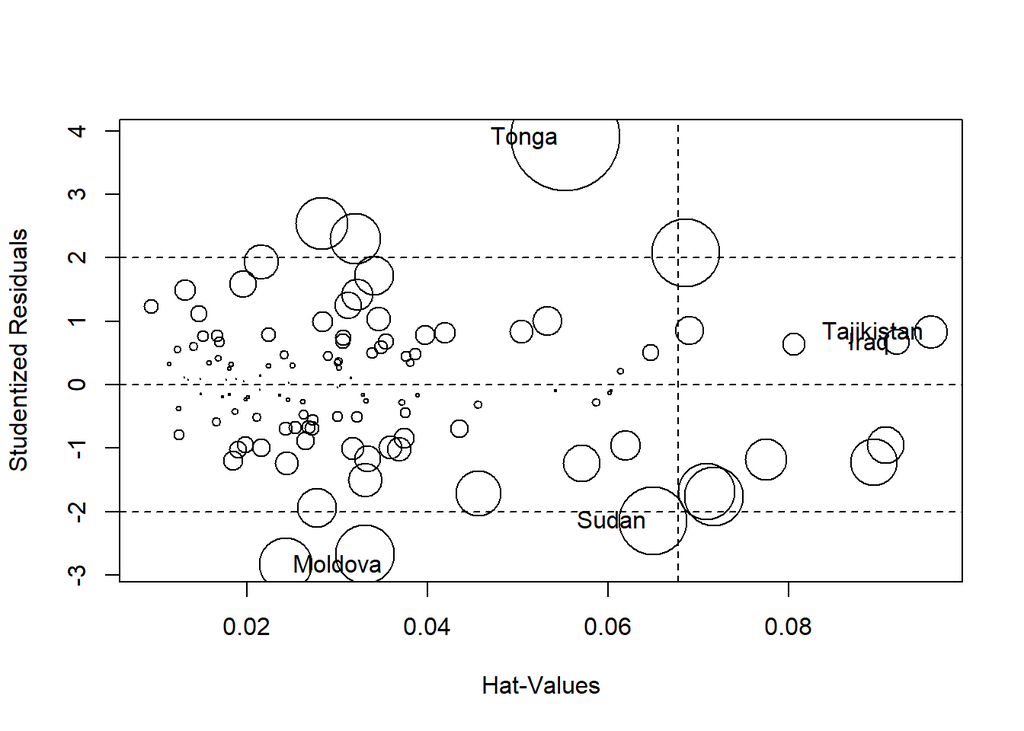

```
##               StudRes        Hat      CookD
## Iraq        0.6657241 0.09196411 0.01127640
## Moldova    -2.8360846 0.02431565 0.04719748
## Sudan      -2.1450482 0.06501132 0.07753357
## Tajikistan  0.8288009 0.09577489 0.01823938
## Tonga       3.9070559 0.05526690 0.19842281
```

```r
influencePlot(un_lm2)
```

```r
# exluding Tonga?
summary(lm(tfr ~ log(GDPperCapita) + log(illiteracyFemale) + contraception, data = un2,
             subset = row.names(un2) != "Tonga"))
```

```
##
## Call:
## lm(formula = tfr ~ log(GDPperCapita) + log(illiteracyFemale) +
##     contraception, data = un2, subset = row.names(un2) != "Tonga")
##
## Residuals:
##      Min       1Q   Median       3Q      Max
## -2.26968 -0.48479 -0.00185  0.49727  2.05735
##
## Coefficients:
##                        Estimate Std. Error t value Pr(>|t|)
## (Intercept)            5.342560   0.452303  11.812  < 2e-16 ***
## log(GDPperCapita)     -0.216454   0.067120  -3.225  0.00165 **
## log(illiteracyFemale)  0.494802   0.049867   9.922  < 2e-16 ***
## contraception         -0.035062   0.004333  -8.091 7.44e-13 ***
## ---
## Signif. codes:  0 '***' 0.001 '**' 0.01 '*' 0.05 '.' 0.1 ' ' 1
##
## Residual standard error: 0.804 on 113 degrees of freedom
## Multiple R-squared:  0.777,  Adjusted R-squared:  0.771
## F-statistic: 131.2 on 3 and 113 DF,  p-value: < 2.2e-16
```

모형진단 결과, 오차의 선형성, 정규성과 등분산성에 문제가 없으며 Component+residual plot 또한 크게 개선된 것으로 보인다. 다만 cook’s distance 수치가 전반적으로 다소 상승하였으며, 지속적으로 Tonga 데이터가 튀고 있는 것으로 보인다. 이에 Tonga 를 제외한 모형을 적합해 본 결과, 다소 수치가 개선되었으나 본래 모형과 큰 차이는 없는 것으로 보여 기존 모형 `un_lm2`를 유지하였다.

#### 2.3 Introducing the factor `region`

##### 2.3.1 Fitting and additive model

```r
un_lm3 <- lm(tfr ~ log(GDPperCapita) + log(illiteracyFemale) + contraception + region, data = un2)
summary(un_lm3)
```

```
##
## Call:
## lm(formula = tfr ~ log(GDPperCapita) + log(illiteracyFemale) +
##     contraception + region, data = un2)
##
## Residuals:
##      Min       1Q   Median       3Q      Max
## -1.79793 -0.44651  0.01122  0.32643  2.34340
##
## Coefficients:
##                        Estimate Std. Error t value Pr(>|t|)
## (Intercept)            6.194247   0.463040  13.377  < 2e-16 ***
## log(GDPperCapita)     -0.220621   0.067832  -3.252  0.00152 **
## log(illiteracyFemale)  0.299507   0.061401   4.878 3.64e-06 ***
## contraception         -0.030977   0.004491  -6.897 3.53e-10 ***
## regionAmerica         -0.505058   0.245030  -2.061  0.04164 *
## regionAsia            -0.536170   0.212904  -2.518  0.01323 *
## regionEurope          -1.656766   0.346862  -4.776 5.54e-06 ***
## regionOceania         -0.194681   0.360201  -0.540  0.58996
## ---
## Signif. codes:  0 '***' 0.001 '**' 0.01 '*' 0.05 '.' 0.1 ' ' 1
##
## Residual standard error: 0.7829 on 110 degrees of freedom
## Multiple R-squared:  0.7942, Adjusted R-squared:  0.7811
## F-statistic: 60.64 on 7 and 110 DF,  p-value: < 2.2e-16
```

```r
anova(un_lm2, un_lm3)
```

```
## Analysis of Variance Table
##
## Model 1: tfr ~ log(GDPperCapita) + log(illiteracyFemale) + contraception
## Model 2: tfr ~ log(GDPperCapita) + log(illiteracyFemale) + contraception +
##     region
##   Res.Df    RSS Df Sum of Sq      F    Pr(>F)
## 1    114 82.916
## 2    110 67.424  4    15.491 6.3183 0.0001294 ***
## ---
## Signif. codes:  0 '***' 0.001 '**' 0.01 '*' 0.05 '.' 0.1 ' ' 1
```

문제에서 요구한 바와 같이 `region`을 추가한 회귀모형을 적합하여 `un_lm3`로 저장하였다. summary 확인 결과, 산점도/상관계수 행렬에서 확인한 바와 같이 지역이라는 factor 변수가 Oceania를 제외하면 통계적으로 유의한 것으로 나타났다. 결정계수는 79% 수즌으로 향상되었으며, anova 결과 또한 유의하게 나타났다.

##### Diagnosis

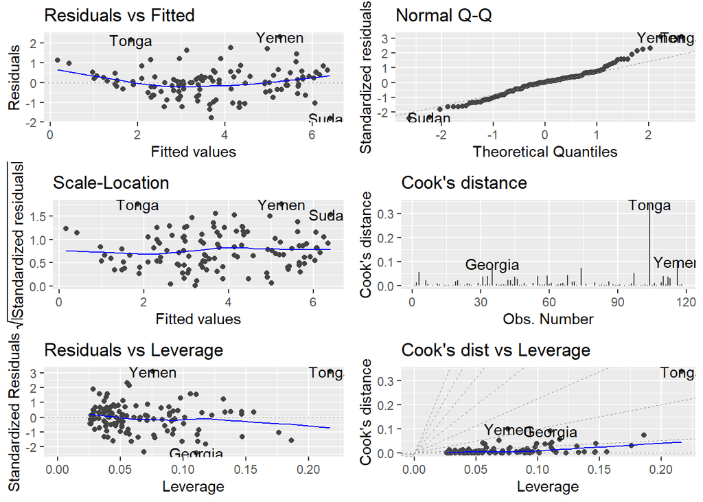

```r
autoplot(un_lm3, which = c(1:6))
```

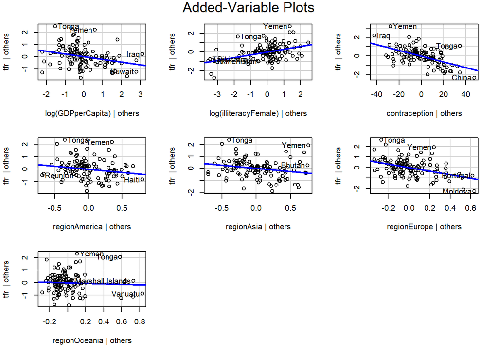

```r
avPlots(un_lm3, ask=FALSE)
```

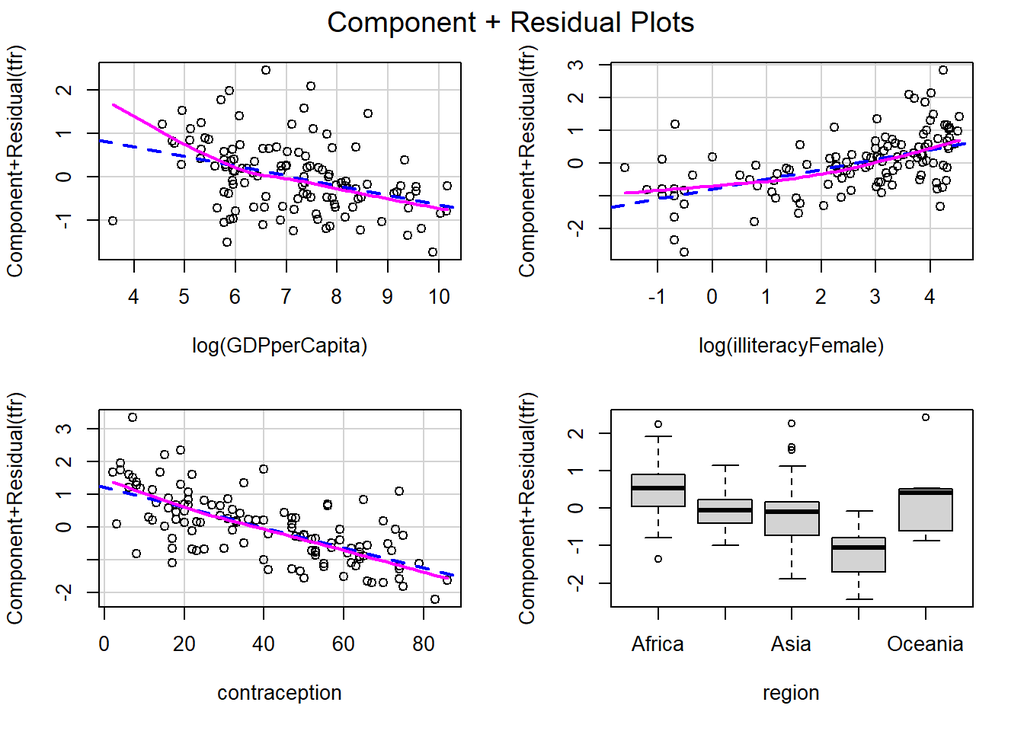

```r
crPlots(un_lm3, ask=FALSE)
```

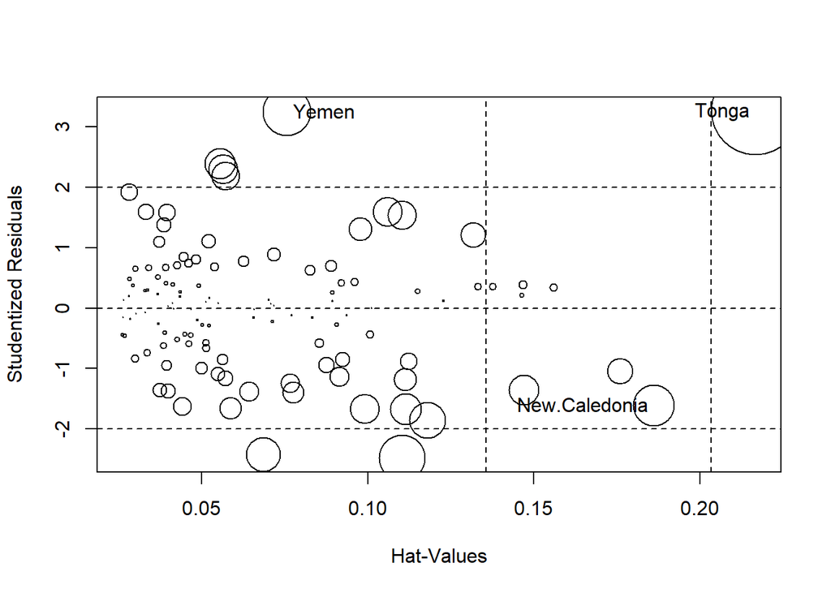

```
##                 StudRes       Hat      CookD
## New.Caledonia -1.612424 0.1861082 0.07324809
## Tonga          3.266682 0.2167754 0.33935192
## Yemen          3.245419 0.0756837 0.09920627
```

```r
influencePlot(un_lm3)
```

모형 진단결과, 기존에는 넘어갔던 Tonga의 영향력이 `region`을 추가한 모형에서는 특히 Oceania 지역에 지나친 영향력을 보이는 사실상의 outlier로 모형의 설명력을 저해하고 있는 것으로 판단되었다.

```r
# Tonga out
un3 <- un2[row.names(un2) != "Tonga",]

un_lm4 <- lm(tfr ~ log(GDPperCapita) + log(illiteracyFemale) + contraception + region, data = un3)
summary(un_lm4)
```

```
##
## Call:
## lm(formula = tfr ~ log(GDPperCapita) + log(illiteracyFemale) +
##     contraception + region, data = un3)
##
## Residuals:
##      Min       1Q   Median       3Q      Max
## -1.77138 -0.44043  0.00588  0.40694  2.18851
##
## Coefficients:
##                        Estimate Std. Error t value Pr(>|t|)
## (Intercept)            5.953066   0.450033  13.228  < 2e-16 ***
## log(GDPperCapita)     -0.188978   0.065751  -2.874  0.00487 **
## log(illiteracyFemale)  0.329775   0.059593   5.534 2.18e-07 ***
## contraception         -0.034139   0.004413  -7.735 5.55e-12 ***
## regionAmerica         -0.409801   0.236723  -1.731  0.08626 .
## regionAsia            -0.455080   0.205624  -2.213  0.02897 *
## regionEurope          -1.507121   0.335691  -4.490 1.78e-05 ***
## regionOceania         -0.536326   0.360829  -1.486  0.14007
## ---
## Signif. codes:  0 '***' 0.001 '**' 0.01 '*' 0.05 '.' 0.1 ' ' 1
##
## Residual standard error: 0.7506 on 109 degrees of freedom
## Multiple R-squared:  0.8125, Adjusted R-squared:  0.8005
## F-statistic: 67.47 on 7 and 109 DF,  p-value: < 2.2e-16
```

이에 Tonga를 제외한 새로운 데이터셋 un3를 바탕으로 모형을 재수립하였다. 비록 기존에 유의하였던 regionAmerica 의 p-value가 증가하였으나 regionOceania는 개선되었고, 결정계수 또한 소폭 개선되었다.

##### 2.3.2 Considering the possibility that region interacts with the other

```r
un_lm5 <- lm(tfr ~ log(GDPperCapita) * region + log(illiteracyFemale) * region +
               contraception * region, data = un3)
summary(un_lm5)
```

```
##
## Call:
## lm(formula = tfr ~ log(GDPperCapita) * region + log(illiteracyFemale) *
##     region + contraception * region, data = un3)
##
## Residuals:
##      Min       1Q   Median       3Q      Max
## -1.72581 -0.33063  0.00319  0.24322  1.91494
##
## Coefficients:
##                                      Estimate Std. Error t value Pr(>|t|)
## (Intercept)                          7.403614   1.682028   4.402 2.76e-05 ***
## log(GDPperCapita)                   -0.087217   0.141297  -0.617  0.53851
## regionAmerica                       -2.304996   2.860935  -0.806  0.42240
## regionAsia                          -1.873552   1.780214  -1.052  0.29522
## regionEurope                        -5.060743   2.434529  -2.079  0.04028 *
## regionOceania                        2.060569   3.528968   0.584  0.56064
## log(illiteracyFemale)               -0.085470   0.332109  -0.257  0.79745
## contraception                       -0.054180   0.009879  -5.484 3.30e-07 ***
## log(GDPperCapita):regionAmerica     -0.166863   0.277354  -0.602  0.54883
## log(GDPperCapita):regionAsia        -0.091390   0.166373  -0.549  0.58406
## log(GDPperCapita):regionEurope      -0.041443   0.345472  -0.120  0.90476
## log(GDPperCapita):regionOceania     -0.450172   0.325509  -1.383  0.16985
## regionAmerica:log(illiteracyFemale)  0.509575   0.408033   1.249  0.21472
## regionAsia:log(illiteracyFemale)     0.464549   0.339471   1.368  0.17433
## regionEurope:log(illiteracyFemale)   0.144240   0.383469   0.376  0.70763
## regionOceania:log(illiteracyFemale) -0.046910   0.515415  -0.091  0.92767
## regionAmerica:contraception          0.033406   0.014983   2.230  0.02808 *
## regionAsia:contraception             0.014889   0.011469   1.298  0.19729
## regionEurope:contraception           0.055350   0.020713   2.672  0.00884 **
## regionOceania:contraception          0.009775   0.047646   0.205  0.83788
## ---
## Signif. codes:  0 '***' 0.001 '**' 0.01 '*' 0.05 '.' 0.1 ' ' 1
##
## Residual standard error: 0.7111 on 97 degrees of freedom
## Multiple R-squared:  0.8502, Adjusted R-squared:  0.8209
## F-statistic: 28.99 on 19 and 97 DF,  p-value: < 2.2e-16
```

```r
anova(un_lm4, un_lm5)
```

```
## Analysis of Variance Table
##
## Model 1: tfr ~ log(GDPperCapita) + log(illiteracyFemale) + contraception +
##     region
## Model 2: tfr ~ log(GDPperCapita) * region + log(illiteracyFemale) * region +
##     contraception * region
##   Res.Df    RSS Df Sum of Sq      F  Pr(>F)
## 1    109 61.412
## 2     97 49.047 12    12.365 2.0378 0.02861 *
## ---
## Signif. codes:  0 '***' 0.001 '**' 0.01 '*' 0.05 '.' 0.1 ' ' 1
```

```r
un_lm6 <- lm(tfr ~ log(GDPperCapita) + log(illiteracyFemale) + contraception * region, data = un3)
summary(un_lm6)
```

```
##
## Call:
## lm(formula = tfr ~ log(GDPperCapita) + log(illiteracyFemale) +
##     contraception * region, data = un3)
##
## Residuals:
##      Min       1Q   Median       3Q      Max
## -1.92271 -0.34648  0.03285  0.34970  2.00771
##
## Coefficients:
##                              Estimate Std. Error t value Pr(>|t|)
## (Intercept)                  6.180752   0.439897  14.050  < 2e-16 ***
## log(GDPperCapita)           -0.193799   0.063635  -3.045 0.002938 **
## log(illiteracyFemale)        0.332035   0.057881   5.736 9.41e-08 ***
## contraception               -0.042705   0.006802  -6.278 7.85e-09 ***
## regionAmerica               -1.098633   0.604473  -1.818 0.071992 .
## regionAsia                  -0.446484   0.347572  -1.285 0.201766
## regionEurope                -3.557876   0.654648  -5.435 3.58e-07 ***
## regionOceania               -1.443123   1.084499  -1.331 0.186176
## contraception:regionAmerica  0.017549   0.011812   1.486 0.140365
## contraception:regionAsia     0.003813   0.008307   0.459 0.647215
## contraception:regionEurope   0.047025   0.012833   3.664 0.000391 ***
## contraception:regionOceania  0.032462   0.034853   0.931 0.353774
## ---
## Signif. codes:  0 '***' 0.001 '**' 0.01 '*' 0.05 '.' 0.1 ' ' 1
##
## Residual standard error: 0.7134 on 105 degrees of freedom
## Multiple R-squared:  0.8368, Adjusted R-squared:  0.8197
## F-statistic: 48.95 on 11 and 105 DF,  p-value: < 2.2e-16
```

```r
anova(un_lm4, un_lm6)
```

```
## Analysis of Variance Table
##
## Model 1: tfr ~ log(GDPperCapita) + log(illiteracyFemale) + contraception +
##     region
## Model 2: tfr ~ log(GDPperCapita) + log(illiteracyFemale) + contraception *
##     region
##   Res.Df    RSS Df Sum of Sq      F   Pr(>F)
## 1    109 61.412
## 2    105 53.444  4    7.9685 3.9139 0.005296 **
## ---
## Signif. codes:  0 '***' 0.001 '**' 0.01 '*' 0.05 '.' 0.1 ' ' 1
```

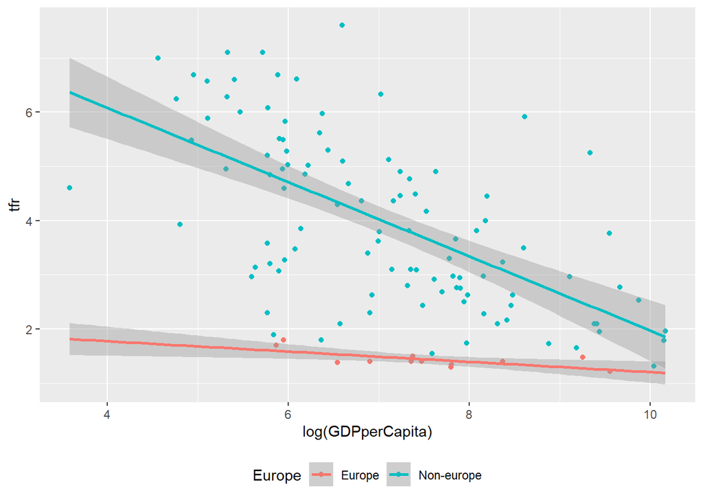

```r
# interaction?
un3 %>% mutate(Europe = ifelse(region == "Europe", "Europe", "Non-europe")) %>%
  ggplot(aes(x = log(GDPperCapita), y = tfr, colour = Europe)) +
  geom_point() + stat_smooth(method = lm, fullrange = TRUE, se = TRUE) +
  theme(legend.position = "bottom")
```

```r
vif(un_lm6)
```

```
##                               GVIF Df GVIF^(1/(2*Df))
## log(GDPperCapita)         1.788595  1        1.337384
## log(illiteracyFemale)     1.970992  1        1.403920
## contraception             5.292330  1        2.300506
## region                 6179.314521  4        2.977608
## contraception:region  11200.652920  4        3.207417
```

위 모형을 참고하여 피임율에만 `region`과의 교호작용을 고려하여 모델을 재설계한 결과, `region`은 Europe인 경우에 한하여 통계적으로 매우 유의하였고, `contraception`와 `regionEurope`의 교호작용 또한 매우 유의한 것으로 나타났으며, anova 결과 또한 유의하였다.

```r
# what if brought Tonga?
summary(lm(tfr ~ log(GDPperCapita) + log(illiteracyFemale) + contraception * region, data = un2))
```

```
##
## Call:
## lm(formula = tfr ~ log(GDPperCapita) + log(illiteracyFemale) +
##     contraception * region, data = un2)
##
## Residuals:
##      Min       1Q   Median       3Q      Max
## -1.92759 -0.34654  0.04233  0.34401  2.00533
##
## Coefficients:
##                              Estimate Std. Error t value Pr(>|t|)
## (Intercept)                  6.185691   0.439937  14.060  < 2e-16 ***
## log(GDPperCapita)           -0.196207   0.063601  -3.085 0.002597 **
## log(illiteracyFemale)        0.333818   0.057863   5.769 7.98e-08 ***
## contraception               -0.042566   0.006802  -6.258 8.42e-09 ***
## regionAmerica               -1.095554   0.604558  -1.812 0.072793 .
## regionAsia                  -0.441123   0.347584  -1.269 0.207182
## regionEurope                -3.550404   0.654707  -5.423 3.72e-07 ***
## regionOceania               -2.304383   0.676556  -3.406 0.000932 ***
## contraception:regionAmerica  0.017532   0.011814   1.484 0.140779
## contraception:regionAsia     0.003731   0.008308   0.449 0.654277
## contraception:regionEurope   0.046996   0.012835   3.661 0.000393 ***
## contraception:regionOceania  0.063255   0.017213   3.675 0.000375 ***
## ---
## Signif. codes:  0 '***' 0.001 '**' 0.01 '*' 0.05 '.' 0.1 ' ' 1
##
## Residual standard error: 0.7135 on 106 degrees of freedom
## Multiple R-squared:  0.8353, Adjusted R-squared:  0.8182
## F-statistic: 48.86 on 11 and 106 DF,  p-value: < 2.2e-16
```

마지막으로 기존에 제외한 `Tonga`의 영향을 확인하기 위해 `Tonga`를 추가한 모형을 적합했을 때, `regionOceania`가 매우 유의하고 `contraception`과도 교호작용함을 확인하는 것으로 나타나고 있으나, 이는 unusual data인 `Tonga`로 인해 과대평가 된 것이라 판단된다. 그러므로 **기존의 모형인 `un_lm6`이 최적의 모형이며, 지역과 피임률 간에는 일부 상호작용이 존재하는 것으로 판단된다.**

### Problem 3

*Using the Canadian occupational prestige data (the Prestige data frame in the car package – see ?Prestige), replicate the linear regression of prestige on education, income, and women (i.e., percent women in the occupation).*

*Use “regression diagnostics” to check for problems in this regression and attempt to correct any problems that you discover.*

#### Data Loading and EDA

```r
data("Prestige")
summary(Prestige)
```

```
##    education          income          women           prestige
##  Min.   : 6.380   Min.   :  611   Min.   : 0.000   Min.   :14.80
##  1st Qu.: 8.445   1st Qu.: 4106   1st Qu.: 3.592   1st Qu.:35.23
##  Median :10.540   Median : 5930   Median :13.600   Median :43.60
##  Mean   :10.738   Mean   : 6798   Mean   :28.979   Mean   :46.83
##  3rd Qu.:12.648   3rd Qu.: 8187   3rd Qu.:52.203   3rd Qu.:59.27
##  Max.   :15.970   Max.   :25879   Max.   :97.510   Max.   :87.20
##      census       type
##  Min.   :1113   bc  :44
##  1st Qu.:3120   prof:31
##  Median :5135   wc  :23
##  Mean   :5402   NA's: 4
##  3rd Qu.:8312
##  Max.   :9517
```

```r
str(Prestige)
```

```
## 'data.frame':    102 obs. of  6 variables:
##  $ education: num  13.1 12.3 12.8 11.4 14.6 ...
##  $ income   : int  12351 25879 9271 8865 8403 11030 8258 14163 11377 11023 ...
##  $ women    : num  11.16 4.02 15.7 9.11 11.68 ...
##  $ prestige : num  68.8 69.1 63.4 56.8 73.5 77.6 72.6 78.1 73.1 68.8 ...
##  $ census   : int  1113 1130 1171 1175 2111 2113 2133 2141 2143 2153 ...
##  $ type     : Factor w/ 3 levels "bc","prof","wc": 2 2 2 2 2 2 2 2 2 2 ...
```

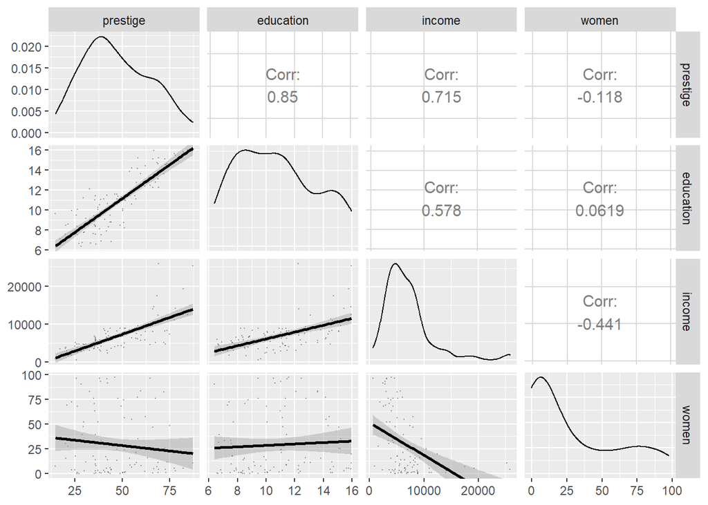

```r
pt <- Prestige %>% select("prestige", "education", "income", "women")

ggpairs(pt, lower = list(continuous = wrap("smooth", alpha = 0.3, size = 0.1)),
        diag = list(discrete="barDiag", continuous = wrap("densityDiag", alpha = 0.5 )),
        upper = list(combo = wrap("box_no_facet", alpha = 0.5),
                     continuous = wrap("cor", size = 4,alignPercent = 0.8))) +
  theme(legend.position = "bottom")
```

`car` 패키지의 데이터 `Prestige`를 로드한 후, 문제에서 주어진 대로 `prestige`, `education`, `income`, `women` 네 변수를 선택해 `pt`로 저장하였다.

산점도/상관계수 행렬을 통해 살펴본 결과, `prestige`와 `education`, `income` 사이에 강한 선형 관계가 관측되며, `women`은 `income`과 음의 상관관계가 있는 것으로 보인다. 데이터의 분포 형태 및 소득 변수 자체의 특성을 감안할 때, `income`은 log transformation이 필요할 것으로 추측되며, `women` 또한 log transformation을 시도할 필요가 있을 것으로 보인다.

#### Model Fitting

*linear regression of prestige on education, income, and women*

```r
pt_lm <- lm(prestige ~ income + education + women, data = pt)
summary(pt_lm)
```

```
##
## Call:
## lm(formula = prestige ~ income + education + women, data = pt)
##
## Residuals:
##      Min       1Q   Median       3Q      Max
## -19.8246  -5.3332  -0.1364   5.1587  17.5045
##
## Coefficients:
##               Estimate Std. Error t value Pr(>|t|)
## (Intercept) -6.7943342  3.2390886  -2.098   0.0385 *
## income       0.0013136  0.0002778   4.729 7.58e-06 ***
## education    4.1866373  0.3887013  10.771  < 2e-16 ***
## women       -0.0089052  0.0304071  -0.293   0.7702
## ---
## Signif. codes:  0 '***' 0.001 '**' 0.01 '*' 0.05 '.' 0.1 ' ' 1
##
## Residual standard error: 7.846 on 98 degrees of freedom
## Multiple R-squared:  0.7982, Adjusted R-squared:  0.792
## F-statistic: 129.2 on 3 and 98 DF,  p-value: < 2.2e-16
```

문제에서 주어진 대로, `prestige`를 종속변수로, `income`, `education`, `women`을 설명변수로 회귀모형 `pt_lm`을 적합하였다. summary 확인 결과, `income`과 `education`은 유의수준 0.05에서 통계적으로 유의하며, F 통계량의 p-value는 매우 유의, 결정계수는 79.8% 수준으로 양호한 것으로 나타났다.

#### Regressioni Diagnostic

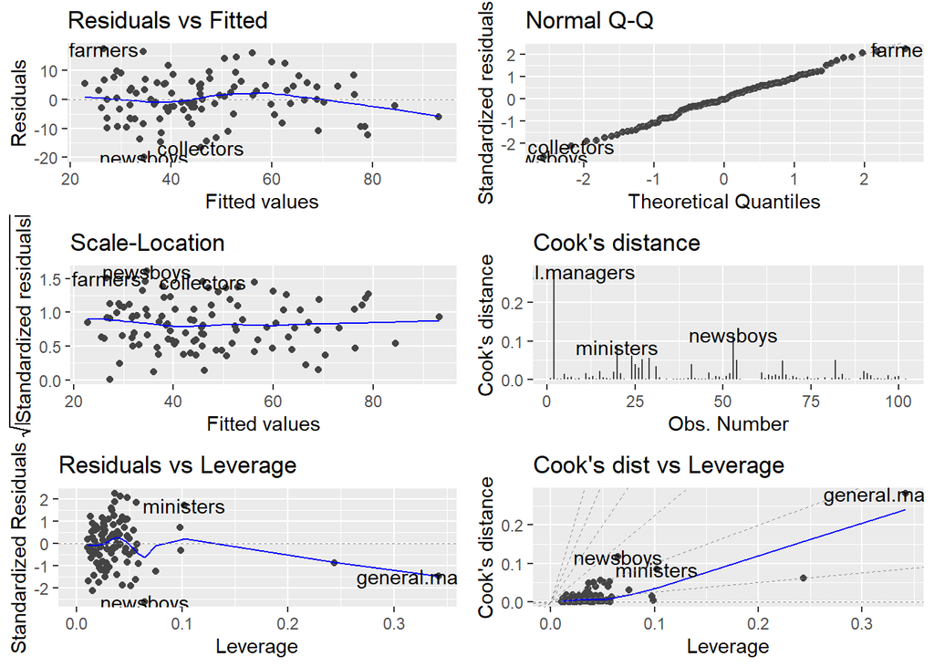

```r
autoplot(pt_lm, which = c(1:6))
```

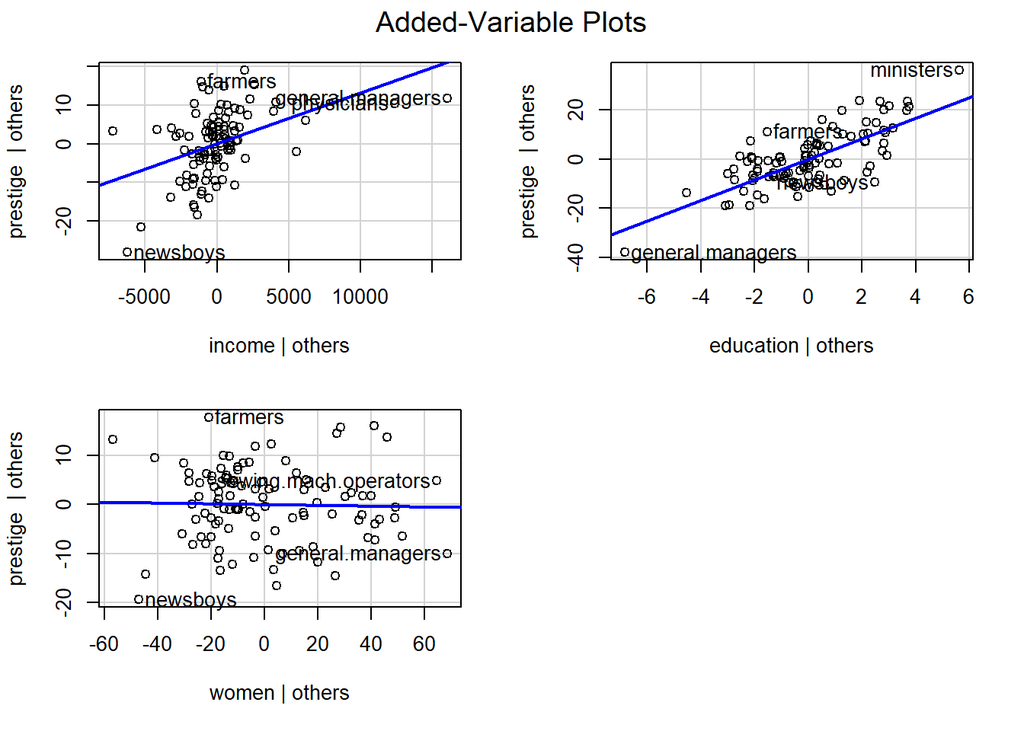

```r
avPlots(pt_lm, ask=FALSE)
```

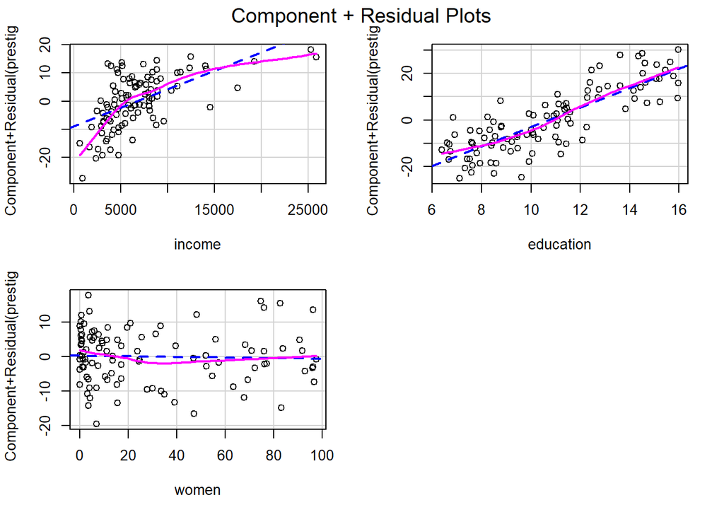

```r
crPlots(pt_lm, ask=FALSE)
```

회귀모형에 대한 diagnostic plot을 통해 검토한 결과, qqplot 상에서 정규성 문제는 없는 것으로 보이며, 스튜던트화잔차 plot에서 오차의 등분산성 문제도 없는 것으로 보인다.

선형성과 관련하여서는 추가적인 검토가 필요한 것으로 보여 Component Residual Plot을 통해 변수별 비선형성 이슈를 검토하였으며, 그 결과 `education`은 큰 이슈가 없으나, `income`은 monotone nonlinearity, `women`은 non-monotone (slight) nonlinearity 이슈가 존재하는 것으로 보인다. 이를 개선하기 위해 두 변수에 대한 변환이 필요한 것으로 판단된다.

Outlier 및 influential 관측치의 경우 general manager가 다소 눈에 띄고 있으나 모델에 영향을 주는 수치는 아닌 것으로 판단된다.

#### Correction

```r
pt_lm2 <- lm(prestige ~ log(income) + education + women, data = pt)
summary(pt_lm2)
```

```
##
## Call:
## lm(formula = prestige ~ log(income) + education + women, data = pt)
##
## Residuals:
##     Min      1Q  Median      3Q     Max
## -17.364  -4.429  -0.101   4.316  19.179
##
## Coefficients:
##              Estimate Std. Error t value Pr(>|t|)
## (Intercept) -110.9658    14.8429  -7.476 3.27e-11 ***
## log(income)   13.4382     1.9138   7.022 2.90e-10 ***
## education      3.7305     0.3544  10.527  < 2e-16 ***
## women          0.0469     0.0299   1.568     0.12
## ---
## Signif. codes:  0 '***' 0.001 '**' 0.01 '*' 0.05 '.' 0.1 ' ' 1
##
## Residual standard error: 7.093 on 98 degrees of freedom
## Multiple R-squared:  0.8351, Adjusted R-squared:   0.83
## F-statistic: 165.4 on 3 and 98 DF,  p-value: < 2.2e-16
```

```r
pt_lm3 <- lm(prestige ~ log(income) + education + poly(women, 2, raw = TRUE), data = pt)
summary(pt_lm3)
```

```
##
## Call:
## lm(formula = prestige ~ log(income) + education + poly(women,
##     2, raw = TRUE), data = pt)
##
## Residuals:
##      Min       1Q   Median       3Q      Max
## -14.8191  -5.5418   0.6296   4.0416  18.5616
##
## Coefficients:
##                               Estimate Std. Error t value Pr(>|t|)
## (Intercept)                 -1.105e+02  1.454e+01  -7.602 1.86e-11 ***
## log(income)                  1.350e+01  1.874e+00   7.204 1.26e-10 ***
## education                    3.770e+00  3.475e-01  10.850  < 2e-16 ***
## poly(women, 2, raw = TRUE)1 -1.391e-01  8.678e-02  -1.603    0.112
## poly(women, 2, raw = TRUE)2  2.149e-03  9.438e-04   2.277    0.025 *
## ---
## Signif. codes:  0 '***' 0.001 '**' 0.01 '*' 0.05 '.' 0.1 ' ' 1
##
## Residual standard error: 6.946 on 97 degrees of freedom
## Multiple R-squared:  0.8435, Adjusted R-squared:  0.837
## F-statistic: 130.7 on 4 and 97 DF,  p-value: < 2.2e-16
```

```r
anova(pt_lm, pt_lm2, pt_lm3)
```

```
## Analysis of Variance Table
##
## Model 1: prestige ~ income + education + women
## Model 2: prestige ~ log(income) + education + women
## Model 3: prestige ~ log(income) + education + poly(women, 2, raw = TRUE)
##   Res.Df    RSS Df Sum of Sq      F  Pr(>F)
## 1     98 6033.6
## 2     98 4929.9  0   1103.68
## 3     97 4679.8  1    250.13 5.1845 0.02499 *
## ---
## Signif. codes:  0 '***' 0.001 '**' 0.01 '*' 0.05 '.' 0.1 ' ' 1
```

```r
step(pt_lm3, direction = "both")
```

```
## Start:  AIC=400.25
## prestige ~ log(income) + education + poly(women, 2, raw = TRUE)
##
##                              Df Sum of Sq     RSS    AIC
## <none>                                     4679.8 400.25
## - poly(women, 2, raw = TRUE)  2     373.9  5053.6 404.09
## - log(income)                 1    2504.1  7183.8 441.97
## - education                   1    5679.1 10358.8 479.30
```

```
##
## Call:
## lm(formula = prestige ~ log(income) + education + poly(women,
##     2, raw = TRUE), data = pt)
##
## Coefficients:
##                 (Intercept)                  log(income)
##                  -1.105e+02                    1.350e+01
##                   education  poly(women, 2, raw = TRUE)1
##                   3.770e+00                   -1.391e-01
## poly(women, 2, raw = TRUE)2
##                   2.149e-03
```

진단결과를 반영하여 모형을 다음과 같이 개선하였다.

1. 먼저 `income` 변수를 log transformaion 하여 새로운 모형 `pt_lm2`를 적합하였다.
2. 추가로 비선형성 이슈를 감안, `women` 변수에 polynomial regression을 시도한 모형 `pt_lm3`을 적합하였다.

`pt_lm` 대비 두 모형 모두 결정계수가 개선되었고, `pt_lm3`에서는 특히 `women`의 2차항이 유의한 것으로 나타나면서 `women` 변수가 처음으로 설명력을 갖게 되었다.

anova 결과에서도 `pt_lm3`가 유의함을 확인할 수 있으며, AIC 기준의 변수 선택 결과에서도 변화가 없었다. 시대적 상황을 고려할 때 `women`의 영향력을 제거하는 모형이 설득력을 갖기 어려운 바, **`pt_lm3`를 최종 모형으로 선택**하였다.

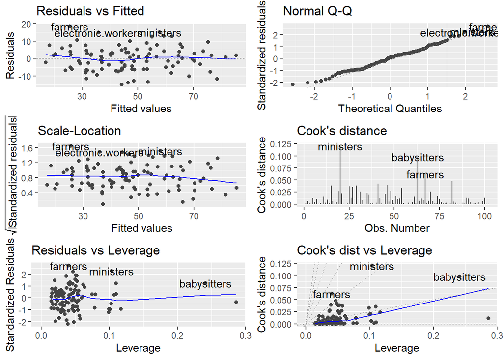

```r
autoplot(pt_lm3, which = c(1:6))
```

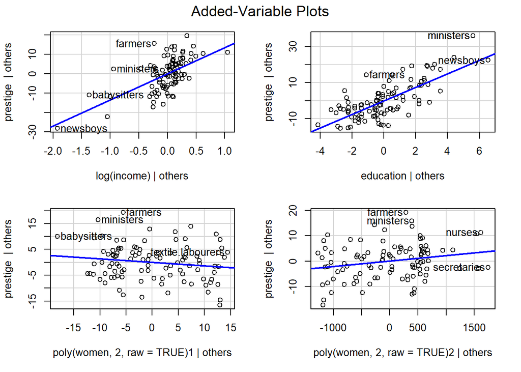

```r
avPlots(pt_lm3, ask=FALSE)
```

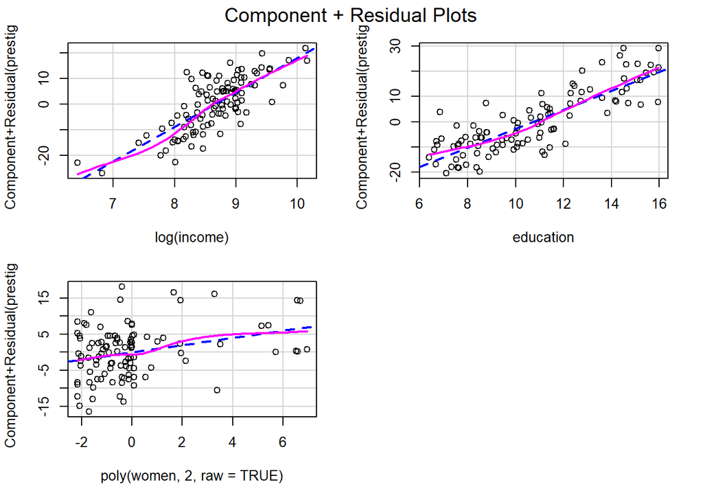

```r
crPlots(pt_lm3, ask=FALSE)
```

```r
vif(pt_lm3)
```

```
##                                GVIF Df GVIF^(1/(2*Df))
## log(income)                2.572891  1        1.604023
## education                  1.881801  1        1.371788
## poly(women, 2, raw = TRUE) 1.819240  2        1.161375
```

Regression diagnostic plot 에서 선형성, 정규성, 등분산성에 문제가 없으며 cook’s distance 수치도 개선되고, outlier, influential 관측치 이슈도 없는 것을 판단된다. Component+residual plot에서도 `income`의 비선형성이 개선되었고, `women`의 nonmonotone 비선형성 이슈도 상대적으로 개선된 것으로 판단된다.